# The Effect of Normality Assumption on Canonical Correlation Analysis: Overthinking & Decision-Making Quality

```r
library(readxl)
library(dplyr)
library(lavaan)
library(semTools)
library(semPlot)
library(MVN)
library(car)
library(CCA)
library(CCP)
library(kernlab)
library(huge)
library(bestNormalize)
library(MASS)
library(lmtest)
```

# Dataset

```r
data <- read_excel("MulVar_dataset.xlsx")

item_map <- list(
  rumination     = paste0("x", 1:4),
  control        = paste0("x", 5:8),
  indecisiveness = paste0("x", 9:12),
  negative       = paste0("x", 13:16),
  regret         = paste0("x", 17:20),
  speed          = paste0("y", 1:4),
  confidence     = paste0("y", 5:8),
  consistency    = paste0("y", 9:12),
  evaluation     = paste0("y", 13:16),
  satisfaction   = paste0("y", 17:20)
)

dims_X <- c("rumination", "control", "indecisiveness", "negative", "regret")
dims_Y <- c("speed", "confidence", "consistency", "evaluation", "satisfaction")

cat("Dataset:", nrow(data), "responden,", ncol(data), "item\n")
```

```
## Dataset: 390 responden, 40 item
```

# Step 1 — Diagram Alur (SEM Path Diagram)

Diagram ini menggambarkan struktur pengukuran keseluruhan dimensi Overthinking (X) dan Kualitas Keputusan (Y) beserta item-itemnya sebelum seleksi validitas dan reliabilitas dilakukan.

```r
model_2order <- paste0(
  paste(sapply(names(item_map), function(d)
    paste0(d, " =~ ", paste(item_map[[d]], collapse = " + "))
  ), collapse = "\n"),
  "\n  Overthinking      =~ ", paste(dims_X, collapse = " + "),
  "\n  KualitasKeputusan =~ ", paste(dims_Y, collapse = " + ")
)

fit_diagram <- sem(model_2order, data = data)

semPaths(fit_diagram,
  what           = "std",
  layout         = "tree2",
  rotation       = 1,
  edge.label.cex = 0.55,
  sizeMan        = 4,
  sizeLat        = 9,
  color = list(lat = c(
    "Overthinking"      = "#C0392B",
    "KualitasKeputusan" = "#1A5276",
    "rumination"        = "#E8A87C",
    "control"           = "#D4856A",
    "indecisiveness"    = "#C06B5A",
    "negative"          = "#A84E3F",
    "regret"            = "#8B3A2F",
    "speed"             = "#AED6F1",
    "confidence"        = "#7FB3D3",
    "consistency"       = "#5499C7",
    "evaluation"        = "#2E86C1",
    "satisfaction"      = "#1A6FA3"
  ), man = "white"),
  edge.color = "gray40",
  label.cex  = 0.7,
  residuals  = FALSE,
  intercepts = FALSE,
  title      = FALSE
)
```

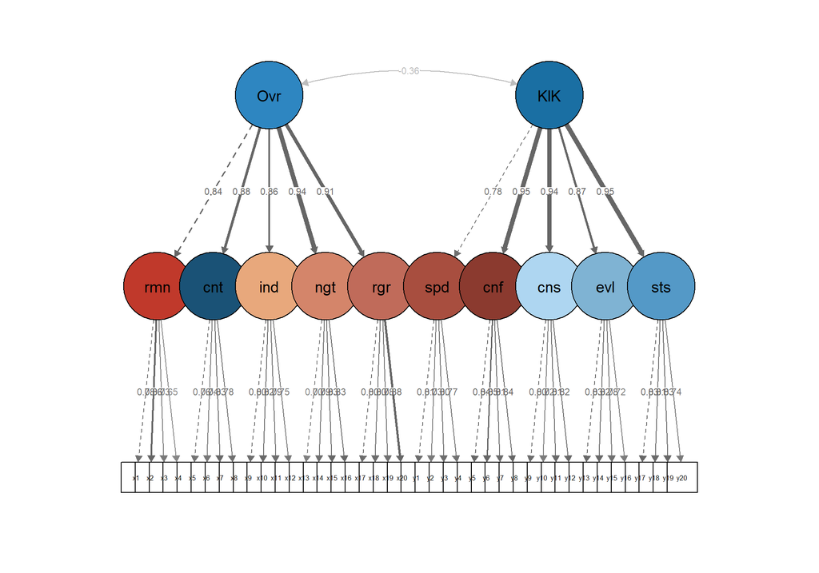

# Step 2 — Uji Validitas (CFA)

Validitas diukur menggunakan Confirmatory Factor Analysis (CFA). Dimensi dinyatakan **valid** jika semua itemnya memiliki standardized loading > 0.7 dan p-value < 0.05.

```r
model_cfa <- paste(
  sapply(names(item_map), function(d)
    paste0(d, " =~ ", paste(item_map[[d]], collapse = " + "))
  ),
  collapse = "\n"
)

fit_cfa <- cfa(model_cfa, data = data)

std_sol  <- standardizedSolution(fit_cfa)
load_tbl <- std_sol[std_sol$op == "=~", c("lhs", "rhs", "est.std", "pvalue")]
load_tbl$status <- ifelse(
  load_tbl$est.std > 0.7 & load_tbl$pvalue < 0.05,
  "VALID", "TIDAK VALID"
)

print(load_tbl)
```

```
##               lhs rhs est.std pvalue      status
## 1      rumination  x1   0.768      0       VALID
## 2      rumination  x2   0.844      0       VALID
## 3      rumination  x3   0.756      0       VALID
## 4      rumination  x4   0.648      0 TIDAK VALID
## 5         control  x5   0.774      0       VALID
## 6         control  x6   0.740      0       VALID
## 7         control  x7   0.818      0       VALID
## 8         control  x8   0.772      0       VALID
## 9  indecisiveness  x9   0.806      0       VALID
## 10 indecisiveness x10   0.818      0       VALID
## 11 indecisiveness x11   0.795      0       VALID
## 12 indecisiveness x12   0.738      0       VALID
## 13       negative x13   0.685      0 TIDAK VALID
## 14       negative x14   0.776      0       VALID
```

[output cut: 26 more lines]

```r
valid_summary <- load_tbl %>%
  group_by(lhs) %>%
  summarise(
    avg_loading = round(mean(abs(est.std)), 3),
    min_loading = round(min(abs(est.std)), 3),
    n_item      = n(),
    n_valid     = sum(status == "VALID"),
    semua_valid = all(status == "VALID")
  ) %>%
  arrange(desc(avg_loading))

print(valid_summary)
```

```
## # A tibble: 10 × 6
##    lhs            avg_loading min_loading n_item n_valid semua_valid
##    <chr>                <dbl>       <dbl>  <int>   <int> <lgl>
##  1 confidence           0.834       0.818      4       4 TRUE
##  2 regret               0.814       0.776      4       4 TRUE
##  3 satisfaction         0.803       0.727      4       4 TRUE
##  4 consistency          0.79        0.723      4       4 TRUE
##  5 evaluation           0.79        0.739      4       4 TRUE
##  6 indecisiveness       0.789       0.738      4       4 TRUE
##  7 negative             0.786       0.685      4       3 FALSE
##  8 control              0.776       0.74       4       4 TRUE
##  9 speed                0.775       0.73       4       4 TRUE
## 10 rumination           0.754       0.648      4       3 FALSE
```

```r
cat("\nModel Fit CFA:\n")
```

```
##
## Model Fit CFA:
```

```r
print(fitMeasures(fit_cfa, c("cfi", "tli", "rmsea", "srmr")))
```

```
##   cfi   tli rmsea  srmr
## 0.898 0.886 0.066 0.057
```

```r
lolos_validitas      <- valid_summary$lhs[valid_summary$semua_valid == TRUE]
tidak_lolos_validitas <- valid_summary$lhs[valid_summary$semua_valid == FALSE]

cat("\nDimensi LOLOS validitas    :", paste(lolos_validitas, collapse = ", "), "\n")
```

```
##
## Dimensi LOLOS validitas    : confidence, regret, satisfaction, consistency, evaluation, indecisiveness, control, speed
```

```r
cat("Dimensi TIDAK LOLOS validitas:", paste(tidak_lolos_validitas, collapse = ", "), "\n")
```

```
## Dimensi TIDAK LOLOS validitas: negative, rumination
```

# Step 3 — Uji Reliabilitas (Omega)

Dimensi dinyatakan **reliabel** jika omega > 0.7. Uji ini tetap dilakukan untuk semua dimensi, namun hanya dimensi yang juga lolos validitas yang akan dibawa ke analisis selanjutnya.

```r
rel_tbl    <- reliability(fit_cfa)
omega_vals <- rel_tbl["omega", ]

cat("Omega per dimensi:\n")
```

```
## Omega per dimensi:
```

```r
print(round(omega_vals, 3))
```

```
##     rumination        control indecisiveness       negative         regret
##          0.843          0.859          0.869          0.873          0.887
##          speed     confidence    consistency     evaluation   satisfaction
##          0.856          0.901          0.868          0.868          0.875
```

```r
lolos_reliabilitas <- names(omega_vals)[omega_vals > 0.7]
cat("\nDimensi LOLOS reliabilitas:", paste(lolos_reliabilitas, collapse = ", "), "\n")
```

```
##
## Dimensi LOLOS reliabilitas: rumination, control, indecisiveness, negative, regret, speed, confidence, consistency, evaluation, satisfaction
```

# Step 4 — Seleksi Dimensi Final

Hanya dimensi yang lolos **keduanya** (validitas DAN reliabilitas) yang digunakan untuk semua analisis selanjutnya.

```r
lolos_semua <- intersect(lolos_validitas, lolos_reliabilitas)
final_X     <- intersect(dims_X, lolos_semua)
final_Y     <- intersect(dims_Y, lolos_semua)

cat("Dimensi X final:", paste(final_X, collapse = ", "), "\n")
```

```
## Dimensi X final: control, indecisiveness, regret
```

```r
cat("Dimensi Y final:", paste(final_Y, collapse = ", "), "\n")
```

```
## Dimensi Y final: speed, confidence, consistency, evaluation, satisfaction
```

```r
# Skor dimensi — hanya dari dimensi yang lolos
skor_list <- lapply(c(final_X, final_Y), function(d)
  rowMeans(data[, item_map[[d]]], na.rm = TRUE))
skor_dim  <- as.data.frame(skor_list)
colnames(skor_dim) <- c(final_X, final_Y)

# Variabel yang dipakai di semua step berikutnya
n_x  <- length(final_X)
n_y  <- length(final_Y)
n    <- nrow(skor_dim)
n_cf <- min(n_x, n_y)

X_raw <- as.matrix(skor_dim[, 1:n_x])
Y_raw <- as.matrix(skor_dim[, (n_x + 1):(n_x + n_y)])
X_sc  <- scale(X_raw)
Y_sc  <- scale(Y_raw)

cat("\nStatistik Deskriptif:\n")
```

```
##
## Statistik Deskriptif:
```

```r
print(round(t(sapply(skor_dim, function(x)
  c(Mean = mean(x), SD = sd(x), Min = min(x),
    Max = max(x), Skew = mean(((x - mean(x)) / sd(x))^3))
)), 3))
```

```
##                 Mean    SD  Min Max   Skew
## control        4.435 1.031 1.50   6 -0.823
## indecisiveness 4.513 1.011 1.25   6 -0.916
## regret         4.231 1.131 1.00   6 -0.776
## speed          3.769 0.887 1.00   6 -0.143
## confidence     3.931 0.914 1.00   6 -0.193
## consistency    3.896 0.905 1.00   6 -0.194
## evaluation     4.341 0.923 1.75   6 -0.165
## satisfaction   4.088 0.877 1.50   6 -0.174
```

# Step 5 — Uji Linearitas (Ramsey RESET Test)

Uji linearitas dilakukan hanya pada dimensi yang sudah lolos seleksi, karena hanya dimensi ini yang masuk ke CCA. Hipotesis nol: hubungan bersifat linear. p > 0.05 berarti linear.

```r
# Y_total dari dimensi Y yang lolos
Y_total <- rowMeans(skor_dim[, (n_x + 1):(n_x + n_y)])

cat(sprintf("%-20s | F-stat  | p-value | Kesimpulan\n", "Dimensi X"))
```

```
## Dimensi X            | F-stat  | p-value | Kesimpulan
```

```r
for (xd in final_X) {
  rst <- resettest(
    lm(Y_total ~ skor_dim[[xd]]),
    power = 2:3,
    type  = "fitted"
  )
  cat(sprintf("%-20s | %7.3f | %7.4f  | %s\n",
    xd, rst$statistic, rst$p.value,
    ifelse(rst$p.value > 0.05, "LINEAR", "NON-LINEAR")))
}
```

```
## control              |   2.322 |  0.0995  | LINEAR
## indecisiveness       |   1.068 |  0.3447  | LINEAR
## regret               |   1.972 |  0.1405  | LINEAR
```

# Step 6 — Uji Normalitas Multivariat (Mardia’s Test)

Uji normalitas multivariat menggunakan Mardia’s skewness dan kurtosis, hanya pada dimensi yang lolos seleksi. p < 0.05 berarti data tidak berdistribusi normal multivariat.

```r
cat("Overthinking (X)\n")
```

```
## Overthinking (X)
```

```r
print(mvn(data = skor_dim[, 1:n_x], mvn = "mardia")$multivariate_normality)
```

```
##              Test Statistic p.value     Method          MVN
## 1 Mardia Skewness   154.200  <0.001 asymptotic ✗ Not normal
## 2 Mardia Kurtosis    11.122  <0.001 asymptotic ✗ Not normal
```

```r
cat("\nDecision-Making Quality (Y)\n")
```

```
##
## Decision-Making Quality (Y)
```

```r
print(mvn(data = skor_dim[, (n_x + 1):(n_x + n_y)], mvn = "mardia")$multivariate_normality)
```

```
##              Test Statistic p.value     Method          MVN
## 1 Mardia Skewness   335.639  <0.001 asymptotic ✗ Not normal
## 2 Mardia Kurtosis    18.741  <0.001 asymptotic ✗ Not normal
```

# Step 7 — Handling Non-Normality: Transformasi Data

Karena data tidak normal, dicoba 8 metode transformasi. Setiap metode dicek apakah berhasil menormalkan distribusi, kemudian dijalankan CCA untuk membandingkan hasilnya.

```r
# Fungsi-fungsi transformasi
boxcox_col <- function(x) {
  bc  <- MASS::boxcox(x ~ 1, lambda = seq(-2, 2, 0.1), plotit = FALSE)
  lam <- bc$x[which.max(bc$y)]
  if (abs(lam) < 0.001) log(x) else (x^lam - 1) / lam
}

yj_col  <- function(x) yeojohnson(x)$x.t
rk_col  <- function(x) qnorm(rank(x) / (length(x) + 1))
orq_col <- function(x) suppressWarnings(orderNorm(x)$x.t)

# NPN transformation
npn_all  <- huge.npn(as.matrix(skor_dim), npn.func = "truncation")
```

```
## Conducting nonparanormal (npn) transformation via truncated ECDF....done.
```

```r
skor_npn <- as.data.frame(npn_all)
colnames(skor_npn) <- c(final_X, final_Y)

# Daftar semua transformasi
transforms <- list(
  "1. Raw (baseline)" = list(X = X_raw,                         Y = Y_raw),
  "2. Log"            = list(X = log(X_raw),                    Y = log(Y_raw)),
  "3. Sqrt"           = list(X = sqrt(X_raw),                   Y = sqrt(Y_raw)),
  "4. Box-Cox"        = list(X = apply(X_raw, 2, boxcox_col),   Y = apply(Y_raw, 2, boxcox_col)),
  "5. Yeo-Johnson"    = list(X = apply(X_raw, 2, yj_col),       Y = apply(Y_raw, 2, yj_col)),
  "6. NPN"            = list(X = as.matrix(skor_npn[, 1:n_x]),  Y = as.matrix(skor_npn[, (n_x+1):(n_x+n_y)])),
  "7. Rank+qnorm"     = list(X = apply(X_raw, 2, rk_col),       Y = apply(Y_raw, 2, rk_col)),
  "8. ORQ"            = list(X = apply(X_raw, 2, orq_col),      Y = apply(Y_raw, 2, orq_col))
)
```

```r
# CEK MVN setelah tiap transformasi
cat(sprintf("%-22s | %-10s | %-10s | %-10s | %-10s | Ket\n",
  "Metode", "X skew p", "X kurt p", "Y skew p", "Y kurt p"))
```

```
## Metode                 | X skew p   | X kurt p   | Y skew p   | Y kurt p   | Ket
```

```r
mvn_summary <- list()
for (nm in names(transforms)) {
  td <- transforms[[nm]]
  mx <- mvn(data = as.data.frame(td$X), mvn = "mardia")$multivariate_normality
  my <- mvn(data = as.data.frame(td$Y), mvn = "mardia")$multivariate_normality

  xp   <- suppressWarnings(as.numeric(mx$p.value[1]))
  yp   <- suppressWarnings(as.numeric(my$p.value[1]))
  x_ok <- !is.na(xp) && xp > 0.05
  y_ok <- !is.na(yp) && yp > 0.05
  ket  <- ifelse(x_ok & y_ok, "NORMAL",
          ifelse(x_ok | y_ok, "PARSIAL", "TIDAK NORMAL"))

  mvn_summary[[nm]] <- list(x_ok = x_ok, y_ok = y_ok)

  cat(sprintf("%-22s | %-10s | %-10s | %-10s | %-10s | %s\n",
    nm, mx$p.value[1], mx$p.value[2],
    my$p.value[1], my$p.value[2], ket))
}
```

```
## 1. Raw (baseline)      | <0.001     | <0.001     | <0.001     | <0.001     | TIDAK NORMAL
## 2. Log                 | <0.001     | <0.001     | <0.001     | <0.001     | TIDAK NORMAL
## 3. Sqrt                | <0.001     | <0.001     | <0.001     | <0.001     | TIDAK NORMAL
## 4. Box-Cox             | 0.001      | <0.001     | <0.001     | <0.001     | TIDAK NORMAL
## 5. Yeo-Johnson         | 0.053      | <0.001     | <0.001     | <0.001     | PARSIAL
## 6. NPN                 | 0.137      | <0.001     | <0.001     | <0.001     | PARSIAL
## 7. Rank+qnorm          | 0.299      | <0.001     | <0.001     | <0.001     | PARSIAL
## 8. ORQ                 | 0.339      | <0.001     | <0.001     | <0.001     | PARSIAL
```

```r
# CCA untuk tiap transformasi
cat(sprintf("%-22s | %s | p_CF1    | p_CF2    | CF_sig\n",
  "Metode",
  paste(sprintf("r%-5d", 1:n_cf), collapse = " | ")))
```

```
## Metode                 | r1     | r2     | r3     | p_CF1    | p_CF2    | CF_sig
```

```r
transform_results <- list()
for (nm in names(transforms)) {
  td  <- transforms[[nm]]
  Xs  <- scale(td$X)
  Ys  <- scale(td$Y)
  res <- cc(Xs, Ys)
  sig <- p.asym(res$cor, nrow(Xs), ncol(Xs), ncol(Ys), tstat = "Wilks")

  transform_results[[nm]] <- list(
    r      = res$cor,
    p_val  = sig$p.value,
    n_sig  = sum(sig$p.value < 0.05, na.rm = TRUE),
    cc_obj = res,
    Xs     = Xs,
    Ys     = Ys
  )

  cat(sprintf("%-22s | %s | %-9.5f| %-9.5f| %d\n",
    nm,
    paste(sprintf("%.4f ", res$cor[1:n_cf]), collapse = " | "),
    sig$p.value[1], sig$p.value[2],
    sum(sig$p.value < 0.05, na.rm = TRUE)))
}
```

```
## Wilks' Lambda, using F-approximation (Rao's F):
##               stat   approx df1      df2      p.value
## 1 to 3:  0.7312007 8.445665  15 1054.935 0.000000e+00
## 2 to 3:  0.8725038 6.757377   8  766.000 1.383974e-08
## 3 to 3:  0.9683572 4.182628   3  384.000 6.236973e-03
## 1. Raw (baseline)      | 0.4024  | 0.3146  | 0.1779  | 0.00000  | 0.00000  | 3
## Wilks' Lambda, using F-approximation (Rao's F):
##               stat   approx df1      df2      p.value
## 1 to 3:  0.7582974 7.414129  15 1054.935 7.771561e-16
## 2 to 3:  0.8853942 6.008439   8  766.000 1.673259e-07
## 3 to 3:  0.9653915 4.588702   3  384.000 3.598671e-03
## 2. Log                 | 0.3789  | 0.2879  | 0.1860  | 0.00000  | 0.00000  | 3
## Wilks' Lambda, using F-approximation (Rao's F):
##               stat   approx df1      df2      p.value
## 1 to 3:  0.7375853 8.197973  15 1054.935 0.000000e+00
## 2 to 3:  0.8739981 6.669709   8  766.000 1.854372e-08
## 3 to 3:  0.9653098 4.599914   3  384.000 3.544373e-03
## 3. Sqrt                | 0.3951  | 0.3076  | 0.1863  | 0.00000  | 0.00000  | 3
## Wilks' Lambda, using F-approximation (Rao's F):
##               stat   approx df1      df2      p.value
## 1 to 3:  0.7437147 7.962913  15 1054.935 0.000000e+00
## 2 to 3:  0.8844301 6.063887   8  766.000 1.392189e-07
## 3 to 3:  0.9743783 3.365811   3  384.000 1.873783e-02
## 4. Box-Cox             | 0.3989  | 0.3038  | 0.1601  | 0.00000  | 0.00000  | 3
## Wilks' Lambda, using F-approximation (Rao's F):
##               stat   approx df1      df2      p.value
## 1 to 3:  0.7462421 7.866756  15 1054.935 0.000000e+00
## 2 to 3:  0.8851039 6.025126   8  766.000 1.583188e-07
## 3 to 3:  0.9746136 3.334106   3  384.000 1.955075e-02
## 5. Yeo-Johnson         | 0.3961  | 0.3031  | 0.1593  | 0.00000  | 0.00000  | 3
## Wilks' Lambda, using F-approximation (Rao's F):
##               stat   approx df1      df2      p.value
## 1 to 3:  0.7529195 7.614826  15 1054.935 2.220446e-16
## 2 to 3:  0.8944510 5.491949   8  766.000 9.220766e-07
## 3 to 3:  0.9763902 3.095130   3  384.000 2.690751e-02
## 6. NPN                 | 0.3978  | 0.2897  | 0.1537  | 0.00000  | 0.00000  | 3
## Wilks' Lambda, using F-approximation (Rao's F):
##               stat   approx df1      df2      p.value
## 1 to 3:  0.7506894 7.698624  15 1054.935 2.220446e-16
## 2 to 3:  0.8894484 5.776263   8  766.000 3.609084e-07
## 3 to 3:  0.9729883 3.553481   3  384.000 1.456683e-02
## 7. Rank+qnorm          | 0.3950  | 0.2930  | 0.1644  | 0.00000  | 0.00000  | 3
## Wilks' Lambda, using F-approximation (Rao's F):
##               stat   approx df1      df2      p.value
## 1 to 3:  0.7504156 7.708936  15 1054.935 1.110223e-16
## 2 to 3:  0.8889813 5.802934   8  766.000 3.304435e-07
## 3 to 3:  0.9718635 3.705736   3  384.000 1.186982e-02
## 8. ORQ                 | 0.3948  | 0.2920  | 0.1677  | 0.00000  | 0.00000  | 3
```

# Step 8 — Distribution-Free Alternative: Kernel CCA

Kernel CCA tidak mentransformasi data dan tidak mensyaratkan normalitas, karena bekerja di ruang kernel (RKHS) yang bebas distribusi. Kernel CCA dimasukkan sebagai pembanding untuk melihat apakah pendekatan non-parametrik menghasilkan r yang berbeda secara signifikan.

```r
cat("Tuning sigma untuk RBF Kernel:\n")
```

```
## Tuning sigma untuk RBF Kernel:
```

```r
cat(sprintf("%-14s | r1      | Ket\n", "Sigma"))
```

```
## Sigma          | r1      | Ket
```

```r
for (s in c(0.01, 0.05, 0.1, 0.5, 1.0)) {
  k  <- kcca(X_sc, Y_sc,
             kernel = "rbfdot",
             kpar   = list(sigma = s),
             ncomps = 1,
             decomp = "chol",
             scale  = FALSE)
  r1 <- round(abs(kcor(k)[1]), 4)
  cat(sprintf("sigma = %-6.2f | %.4f  | %s\n",
    s, r1, ifelse(r1 > 0.99, "OVERFIT", "OK")))
}
```

```
## sigma = 0.01   | 0.9996  | OVERFIT
## sigma = 0.05   | 0.9991  | OVERFIT
## sigma = 0.10   | 0.9986  | OVERFIT
## sigma = 0.50   | 0.9953  | OVERFIT
## sigma = 1.00   | 0.9917  | OVERFIT
```

```r
kcca_lin  <- kcca(X_sc, Y_sc,
                  kernel = "vanilladot", kpar = list(),
                  ncomps = n_cf, decomp = "chol", scale = FALSE)

kcca_rbf  <- kcca(X_sc, Y_sc,
                  kernel = "rbfdot", kpar = list(sigma = 0.1),
                  ncomps = n_cf, decomp = "chol", scale = FALSE)

kcca_poly <- kcca(X_sc, Y_sc,
                  kernel = "polydot",
                  kpar   = list(degree = 2, scale = 1, offset = 1),
                  ncomps = n_cf, decomp = "chol", scale = FALSE)

kernel_results <- list(
  "9.  kCCA Linear"      = abs(kcor(kcca_lin)),
  "10. kCCA RBF (s=0.1)" = abs(kcor(kcca_rbf)),
  "11. kCCA Poly (d=2)"  = abs(kcor(kcca_poly))
)

cat(sprintf("%-24s | %s | Ket\n",
  "Metode",
  paste(sprintf("r%-5d", 1:n_cf), collapse = " | ")))
```

```
## Metode                   | r1     | r2     | r3     | Ket
```

```r
for (nm in names(kernel_results)) {
  r <- kernel_results[[nm]]
  cat(sprintf("%-24s | %s | %s\n",
    nm,
    paste(sprintf("%.4f ", r[1:n_cf]), collapse = " | "),
    ifelse(max(r) > 0.95, "OVERFIT", "OK")))
}
```

```
## 9.  kCCA Linear          | 0.4023  | 0.4023  | 0.3144  | OK
## 10. kCCA RBF (s=0.1)     | 0.9986  | 0.9986  | 0.6726  | OVERFIT
## 11. kCCA Poly (d=2)      | 0.9997  | 0.9997  | 0.5255  | OVERFIT
```

# Step 9 — Perbandingan Semua Metode

Semua 11 metode (8 transformasi + 3 kernel) dibandingkan dalam satu tabel. **Apakah metode normality handling mempengaruhi hasil CCA?**

```r
cat(sprintf("%-24s| %-9s| %s | %-9s| %-9s| %-6s| %s\n",
  "Metode", "Tipe",
  paste(sprintf("r%-5d ", 1:n_cf), collapse = "| "),
  "p_CF1", "p_CF2", "n_sig", "Ket"))
```

```
## Metode                  | Tipe     | r1     | r2     | r3      | p_CF1    | p_CF2    | n_sig | Ket
```

```r
# transformasi
for (nm in names(transform_results)) {
  res <- transform_results[[nm]]
  cat(sprintf("%-24s| %-9s| %s | %-9.5f| %-9.5f| %-6d| %s\n",
    nm, "Transf.",
    paste(sprintf("%.4f  ", res$r[1:n_cf]), collapse = "| "),
    res$p_val[1], res$p_val[2], res$n_sig,
    ifelse(res$p_val[1] < 0.05, "OK", "NS")))
}
```

```
## 1. Raw (baseline)       | Transf.  | 0.4024  | 0.3146  | 0.1779   | 0.00000  | 0.00000  | 3     | OK
## 2. Log                  | Transf.  | 0.3789  | 0.2879  | 0.1860   | 0.00000  | 0.00000  | 3     | OK
## 3. Sqrt                 | Transf.  | 0.3951  | 0.3076  | 0.1863   | 0.00000  | 0.00000  | 3     | OK
## 4. Box-Cox              | Transf.  | 0.3989  | 0.3038  | 0.1601   | 0.00000  | 0.00000  | 3     | OK
## 5. Yeo-Johnson          | Transf.  | 0.3961  | 0.3031  | 0.1593   | 0.00000  | 0.00000  | 3     | OK
## 6. NPN                  | Transf.  | 0.3978  | 0.2897  | 0.1537   | 0.00000  | 0.00000  | 3     | OK
## 7. Rank+qnorm           | Transf.  | 0.3950  | 0.2930  | 0.1644   | 0.00000  | 0.00000  | 3     | OK
## 8. ORQ                  | Transf.  | 0.3948  | 0.2920  | 0.1677   | 0.00000  | 0.00000  | 3     | OK
```

```r
# kernel
for (nm in names(kernel_results)) {
  r <- kernel_results[[nm]]
  cat(sprintf("%-24s| %-9s| %s | %-9s| %-9s| %-6s| %s\n",
    nm, "Kernel",
    paste(sprintf("%.4f  ", r[1:n_cf]), collapse = "| "),
    "N/A", "N/A", "N/A",
    ifelse(max(r) > 0.95, "OVERFIT", "OK")))
}
```

```
## 9.  kCCA Linear         | Kernel   | 0.4023  | 0.4023  | 0.3144   | N/A      | N/A      | N/A   | OK
## 10. kCCA RBF (s=0.1)    | Kernel   | 0.9986  | 0.9986  | 0.6726   | N/A      | N/A      | N/A   | OVERFIT
## 11. kCCA Poly (d=2)     | Kernel   | 0.9997  | 0.9997  | 0.5255   | N/A      | N/A      | N/A   | OVERFIT
```

# Step 10 — Uji Multikolinearitas

Multikolinearitas dicek menggunakan VIF dan Tolerance pada dimensi X final. VIF < 10 dan Tolerance > 0.1 berarti tidak ada masalah.

```r
skor_vif         <- skor_dim
skor_vif$Y_total <- rowMeans(skor_dim[, (n_x + 1):(n_x + n_y)])

vif_formula <- as.formula(
  paste("Y_total ~", paste(final_X, collapse = " + "))
)
vif_model <- lm(vif_formula, data = skor_vif)

cat("Korelasi antar dimensi X:\n")
```

```
## Korelasi antar dimensi X:
```

```r
print(round(cor(X_raw), 3))
```

```
##                control indecisiveness regret
## control          1.000          0.647  0.672
## indecisiveness   0.647          1.000  0.701
## regret           0.672          0.701  1.000
```

```r
cat("\nVIF dan Tolerance:\n")
```

```
##
## VIF dan Tolerance:
```

```r
vif_vals <- vif(vif_model)
print(data.frame(
  VIF       = round(vif_vals, 3),
  Tolerance = round(1 / vif_vals, 3),
  Status    = ifelse(vif_vals < 10, "AMAN", "MASALAH")
))
```

```
##                  VIF Tolerance Status
## control        2.051     0.487   AMAN
## indecisiveness 2.210     0.453   AMAN
## regret         2.345     0.426   AMAN
```

# Step 11 — CCA Detail: Metode Terbaik

Dipilih otomatis dari transformasi: r CF1 tertinggi dengan p_CF1 < 0.05 dan r tidak overfit (< 0.95)

```r
best_nm <- names(which.max(
  sapply(transform_results, function(r)
    ifelse(r$p_val[1] < 0.05 & max(r$r) < 0.95, r$r[1], 0))
))
best <- transform_results[[best_nm]]

cat("Metode terpilih :", best_nm, "\n")
```

```
## Metode terpilih : 1. Raw (baseline)
```

```r
cat(sprintf("r CF1 = %.4f | r CF2 = %.4f | CF signifikan = %d\n",
  best$r[1], best$r[2], best$n_sig))
```

```
## r CF1 = 0.4024 | r CF2 = 0.3146 | CF signifikan = 3
```

```r
cc_load <- comput(best$Xs, best$Ys, best$cc_obj)

load_x <- cc_load$corr.X.xscores
load_y <- cc_load$corr.Y.yscores
rownames(load_x) <- final_X
rownames(load_y) <- final_Y
colnames(load_x) <- paste0("CF", 1:n_cf)
colnames(load_y) <- paste0("CF", 1:n_cf)

cat("Canonical Loadings X (|loading| >= 0.5 dianggap substantif):\n")
```

```
## Canonical Loadings X (|loading| >= 0.5 dianggap substantif):
```

```r
print(round(load_x, 4))
```

```
##                   CF1     CF2     CF3
## control        0.6268 -0.6060 -0.4897
## indecisiveness 0.9910  0.0561 -0.1217
## regret         0.7759 -0.5527  0.3043
```

```r
cat("\nCanonical Loadings Y:\n")
```

```
##
## Canonical Loadings Y:
```

```r
print(round(load_y, 4))
```

```
##                  CF1     CF2     CF3
## speed        -0.8542 -0.4549  0.0397
## confidence   -0.9625  0.1271 -0.2187
## consistency  -0.7110 -0.0026 -0.5654
## evaluation   -0.6753  0.4326  0.0818
## satisfaction -0.7586  0.3058 -0.3100
```

```r
wx <- best$cc_obj$xcoef
wy <- best$cc_obj$ycoef
rownames(wx) <- final_X
rownames(wy) <- final_Y
colnames(wx) <- paste0("CF", 1:n_cf)
colnames(wy) <- paste0("CF", 1:n_cf)

cat("Canonical Weights X:\n")
```

```
## Canonical Weights X:
```

```r
print(round(wx, 4))
```

```
##                    CF1     CF2     CF3
## control        -0.1007 -0.7950 -1.1872
## indecisiveness  0.9137  1.1458 -0.2485
## regret          0.2032 -0.8213  1.2765
```

```r
cat("\nCanonical Weights Y:\n")
```

```
##
## Canonical Weights Y:
```

```r
print(round(wy, 4))
```

```
##                  CF1     CF2     CF3
## speed        -0.3600 -1.1466  0.6723
## confidence   -0.8385  0.6110  0.0812
## consistency   0.2922 -0.5480 -1.4078
## evaluation   -0.1174  0.5265  0.9436
## satisfaction -0.0184  0.5608 -0.3804
```

```r
cat("Signifikansi Wilks Lambda:\n")
```

```
## Signifikansi Wilks Lambda:
```

```r
cat(sprintf("%-5s| %-7s | %-10s | %s\n", "CF", "r", "p-value", "Ket"))
```

```
## CF   | r       | p-value    | Ket
```

```r
for (i in 1:n_cf) {
  cat(sprintf("CF%-3d| %.4f  | %.5f    | %s\n",
    i, best$r[i], best$p_val[i],
    ifelse(best$p_val[i] < 0.05, "SIGNIFIKAN*", "tidak signifikan")))
}
```

```
## CF1  | 0.4024  | 0.00000    | SIGNIFIKAN*
## CF2  | 0.3146  | 0.00000    | SIGNIFIKAN*
## CF3  | 0.1779  | 0.00624    | SIGNIFIKAN*
```

```r
lx1   <- load_x[, 1]
ly1   <- load_y[, 1]
dom_x <- names(lx1)[abs(lx1) >= 0.5]
dom_y <- names(ly1)[abs(ly1) >= 0.5]

cat("Dimensi X dominan di CF1 (|loading| >= 0.5):\n")
```

```
## Dimensi X dominan di CF1 (|loading| >= 0.5):
```

```r
if (length(dom_x) > 0) {
  for (nm in dom_x)
    cat(sprintf("  %-20s loading = %.4f\n", nm, lx1[nm]))
} else {
  cat("  Tidak ada\n")
}
```

```
##   control              loading = 0.6268
##   indecisiveness       loading = 0.9910
##   regret               loading = 0.7759
```

```r
cat("\nDimensi Y dominan di CF1 (|loading| >= 0.5):\n")
```

```
##
## Dimensi Y dominan di CF1 (|loading| >= 0.5):
```

```r
if (length(dom_y) > 0) {
  for (nm in dom_y)
    cat(sprintf("  %-20s loading = %.4f\n", nm, ly1[nm]))
} else {
  cat("  Tidak ada\n")
}
```

```
##   speed                loading = -0.8542
##   confidence           loading = -0.9625
##   consistency          loading = -0.7110
##   evaluation           loading = -0.6753
##   satisfaction         loading = -0.7586
```

# Step 12 — Ringkasan Final

```r
cat(sprintf("\nDimensi X final : %s\n", paste(final_X, collapse = ", ")))
```

```
##
## Dimensi X final : control, indecisiveness, regret
```

```r
cat(sprintf("Dimensi Y final : %s\n", paste(final_Y, collapse = ", ")))
```

```
## Dimensi Y final : speed, confidence, consistency, evaluation, satisfaction
```

```r
cat(sprintf("n               : %d responden\n\n", n))
```

```
## n               : 390 responden
```

```r
cat("Transformasi\n")
```

```
## Transformasi
```

```r
tr_r1 <- sapply(transform_results, function(r) r$r[1])
for (nm in names(sort(tr_r1, decreasing = TRUE))) {
  res <- transform_results[[nm]]
  cat(sprintf("  %-22s | r1=%.4f | CF sig=%d | %s\n",
    nm, res$r[1], res$n_sig,
    ifelse(res$p_val[1] < 0.05, "Signifikan", "Tidak Signifikan")))
}
```

```
##   1. Raw (baseline)      | r1=0.4024 | CF sig=3 | Signifikan
##   4. Box-Cox             | r1=0.3989 | CF sig=3 | Signifikan
##   6. NPN                 | r1=0.3978 | CF sig=3 | Signifikan
##   5. Yeo-Johnson         | r1=0.3961 | CF sig=3 | Signifikan
##   3. Sqrt                | r1=0.3951 | CF sig=3 | Signifikan
##   7. Rank+qnorm          | r1=0.3950 | CF sig=3 | Signifikan
##   8. ORQ                 | r1=0.3948 | CF sig=3 | Signifikan
##   2. Log                 | r1=0.3789 | CF sig=3 | Signifikan
```

```r
cat("\nKernel CCA\n")
```

```
##
## Kernel CCA
```

```r
for (nm in names(kernel_results)) {
  r <- kernel_results[[nm]]
  cat(sprintf("  %-24s | r1=%.4f | %s\n",
    nm, r[1],
    ifelse(max(r) > 0.95, "OVERFIT", "OK")))
}
```

```
##   9.  kCCA Linear          | r1=0.4023 | OK
##   10. kCCA RBF (s=0.1)     | r1=0.9986 | OVERFIT
##   11. kCCA Poly (d=2)      | r1=0.9997 | OVERFIT
```

```r
cat(sprintf("\nMETODE TERPILIH : %s\n", best_nm))
```

```
##
## METODE TERPILIH : 1. Raw (baseline)
```

```r
cat(sprintf("r CF1           : %.4f\n", best$r[1]))
```

```
## r CF1           : 0.4024
```

```r
cat(sprintf("r CF2           : %.4f\n", best$r[2]))
```

```
## r CF2           : 0.3146
```

```r
cat(sprintf("CF signifikan   : %d dari %d\n", best$n_sig, n_cf))
```

```
## CF signifikan   : 3 dari 3
```